# Analyzing Individual BGG Users

Phil Henrickson

2022-01-02

# **jimmyhill27’s** BoardGameGeek Collection

This notebook contains a set of analyses for the selected user’s boardgamegeek collection. The bulk of the analysis is focused on building a user-specific predictive model to predict the games that jimmyhill27 is likely to own. This enables to ask questions like, based on the games the user currently owns, what games are a good fit for their collection? What upcoming games are they likely to purchase?

This analysis is based on data from BoardGameGeek that was last updated on **2021-12-20.**

# 1 Collection Overview

We can look at a basic description of the number of games that the user owns, has rated, has previously owned, etc.

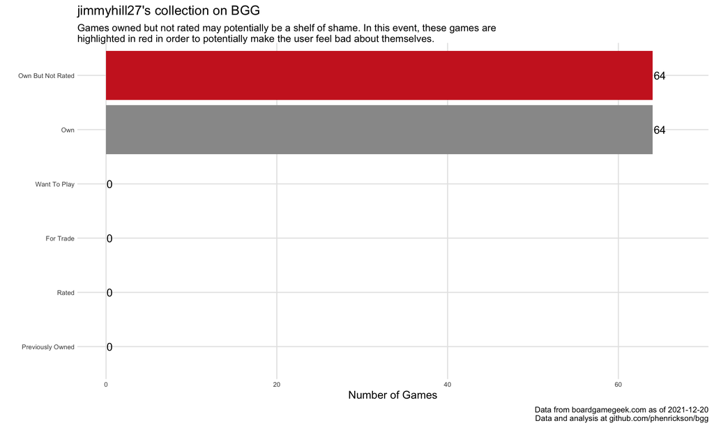

What years has the user owned/rated games from? While we can’t see when a user added or removed a game from their collection, we can look at their collection by the years in which their games were published.

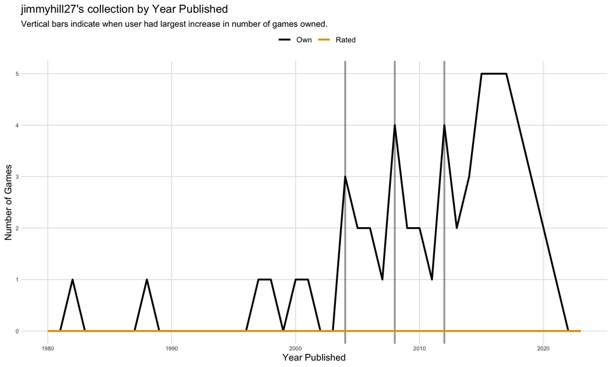

## 1.1 What types of games does jimmyhill27 own?

We can look at the most frequent types of categories, mechanics, designers, and artists that appear in a user’s collection.

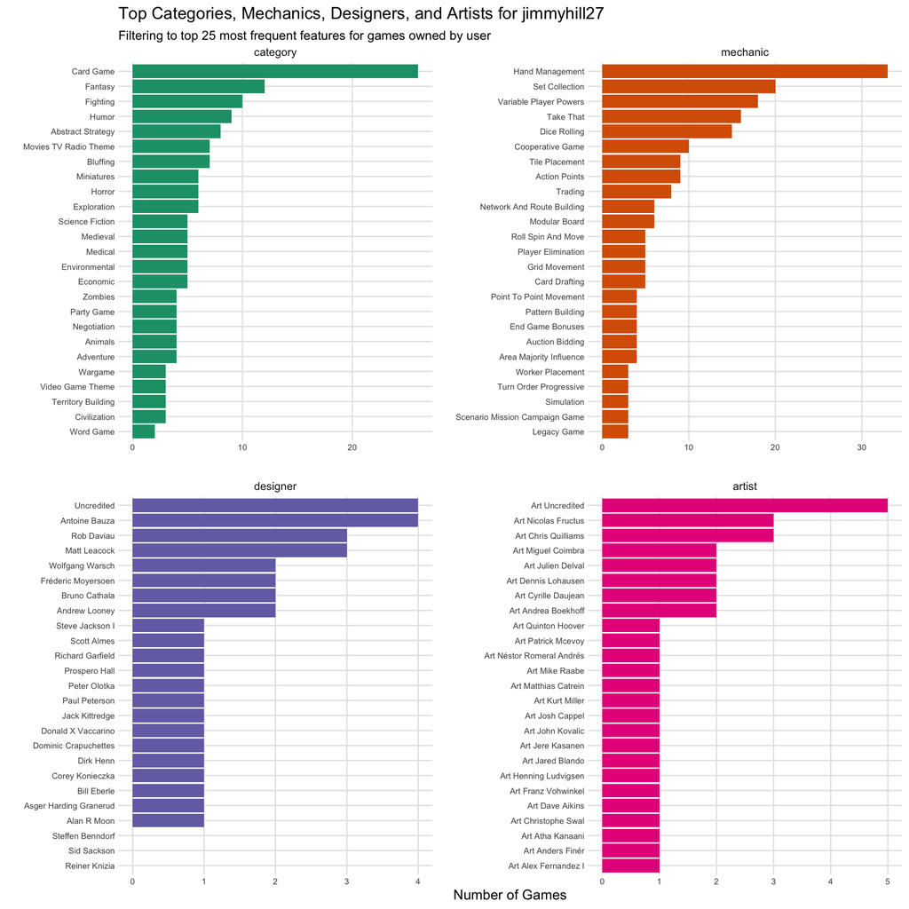

# 2 Modeling **jimmyhill27’s** Collection

| username | dataset | period | games_owned | games_rated | games_played |
| --- | --- | --- | --- | --- | --- |
| jimmyhill27 | training | published before 2020 | 58 | 0 | 58 |
| jimmyhill27 | test | published 2020 or later | 3 | 0 | 3 |

There are two main (binary) outcomes we will be modeling for the user.

The first, **own** refers to whether the user currently lists a game as owned in their collection. The second, **played** refers to whether the user currently owns, has rated, or previously owned a game. This means the latter will generally have a larger list of games, but may still be a useful category to examine for people who play lots of games without necessarily owning them.

We will train predictive models to learn the probability that the user will own or play individual games based on their features.

## 2.1 Coefficients for jimmyhill27

We can examine coefficients from the trained modes, which are penalized logistic regressions fit to our two main outcomes. Positive values indicate that a feature increases a user’s probabilility of owning/rating a game, while negative values indicate a feature decreases the probability.

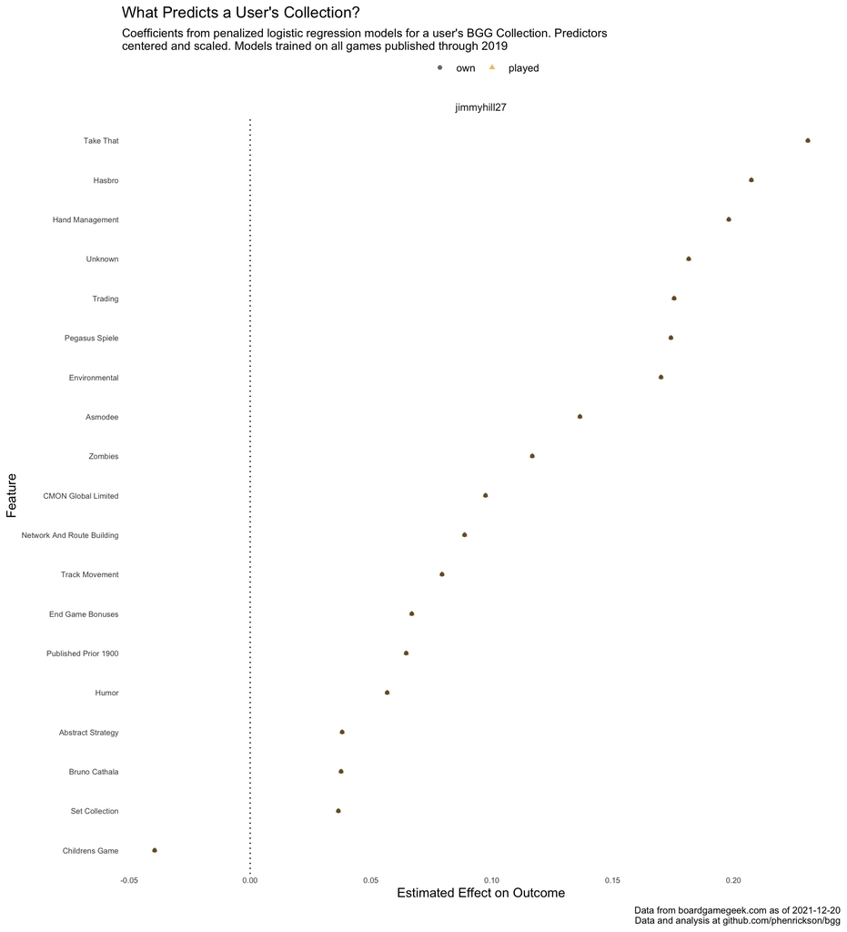

## 2.2 Visualizing Predictors for jimmyhill27’s Collection

Why did the model identify these features? We can make density plots of the important features for predicting whether the user owned a game. Blue indicates the density for games owned by the user, while grey indicates the density for games not owned by the user.

[figure not shown]

Binary predictors can be difficult to see with this visualization, so we can also directly examine the percentage of games in a user’s collection with a predictor vs the percentage of all games with that predictor.

| username | Feature | % of Games with Feature In_Collection | % of Games with Feature All_Games | Ratio |
| --- | --- | --- | --- | --- |
| jimmyhill27 | Unknown | 13.8% | 1.4% | 9.8 |
| jimmyhill27 | Published Prior 1900 | 6.9% | 0.8% | 8.2 |
| jimmyhill27 | Environmental | 8.6% | 1.1% | 8.1 |
| jimmyhill27 | Track Movement | 5.2% | 0.6% | 8.1 |
| jimmyhill27 | CMON Global Limited | 5.2% | 0.8% | 6.5 |
| jimmyhill27 | Zombies | 6.9% | 1.2% | 5.5 |
| jimmyhill27 | End Game Bonuses | 6.9% | 1.3% | 5.5 |
| jimmyhill27 | Hasbro | 17.2% | 3.8% | 4.5 |
| jimmyhill27 | Trading | 13.8% | 3.1% | 4.4 |
| jimmyhill27 | Mattel | 5.2% | 1.3% | 4.1 |
| jimmyhill27 | Take That | 25.9% | 6.5% | 4.0 |
| jimmyhill27 | Pegasus Spiele | 19.0% | 4.7% | 4.0 |
| jimmyhill27 | Asmodee | 17.2% | 5.3% | 3.2 |
| jimmyhill27 | Video Game Theme | 5.2% | 1.7% | 3.1 |
| jimmyhill27 | Humor | 15.5% | 5.6% | 2.8 |
| jimmyhill27 | Horror | 10.3% | 3.9% | 2.6 |
| jimmyhill27 | Network And Route Building | 10.3% | 4.1% | 2.5 |
| jimmyhill27 | Abstract Strategy | 13.8% | 6.3% | 2.2 |
| jimmyhill27 | Action Points | 13.8% | 6.9% | 2.0 |
| jimmyhill27 | Word Game | 3.4% | 1.8% | 2.0 |
| jimmyhill27 | Hand Management | 51.7% | 26.6% | 1.9 |
| jimmyhill27 | Set Collection | 32.8% | 17.5% | 1.9 |
| jimmyhill27 | Animals | 3.4% | 6.9% | 0.5 |
| jimmyhill27 | Childrens Game | 0.0% | 5.7% | 0.0 |
| jimmyhill27 | Alderac Entertainment Group | 0.0% | 1.6% | 0.0 |

# 3 Assess Model’s Performance on Training Set

Before predicting games in upcoming years, we can examine how well the model did and what games it liked in the training set. In this case, we used resampling techniques (cross validation) to ensure that the model had not seen a game before making its predictions.

## 3.1 Separation Plot

An easy way to examine the performance of classification model is to view a separation plot. We plot the predicted probabilities from the model for every game (from resampling) from lowest to highest. We then overlay a blue line for any game that the user does own. A good classifier is one that is able to *separate* the blue (games owned by the user) from the white (games not owned by the user), with most of the blue occurring at the highest probabilities (right side of the chart).

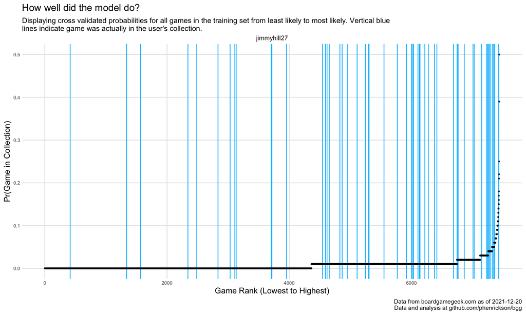

## 3.2 Top Games for **jimmyhill27** from Training Set

We can display this information in table form, displaying the 100 games with the highest probability of ownership, adding a blue line when the user does own the game.

| username | yearpublished | game_id | name | pred_played | pred_own | actual_played | actual_own |
| --- | --- | --- | --- | --- | --- | --- | --- |
| jimmyhill27 | 1959 | 7688 | Memory | 0.50 | 0.50 | 0 | 0 |
| jimmyhill27 | 1900 | 45 | Perudo | 0.39 | 0.39 | 0 | 0 |
| jimmyhill27 | 2015 | 172242 | Exploding Kittens: NSFW Deck | 0.25 | 0.25 | 0 | 0 |
| jimmyhill27 | 1900 | 15878 | Rummy | 0.22 | 0.22 | 0 | 0 |
| jimmyhill27 | 1997 | 2633 | DOG | 0.21 | 0.21 | 0 | 0 |
| jimmyhill27 | 2017 | 195539 | The Godfather: Corleone's Empire | 0.18 | 0.18 | 0 | 0 |
| jimmyhill27 | 1933 | 1406 | Monopoly | 0.17 | 0.17 | 0 | 0 |
| jimmyhill27 | 2018 | 205896 | Rising Sun | 0.16 | 0.16 | 0 | 0 |
| jimmyhill27 | 2017 | 221107 | Pandemic Legacy: Season 2 | 0.15 | 0.15 | 1 | 1 |
| jimmyhill27 | 2013 | 124548 | The Doom That Came to Atlantic City | 0.15 | 0.15 | 0 | 0 |
| jimmyhill27 | 2001 | 1927 | Munchkin | 0.15 | 0.15 | 1 | 1 |
| jimmyhill27 | 2019 | 226605 | Fire Tower | 0.14 | 0.14 | 0 | 0 |
| jimmyhill27 | 1955 | 1475 | Careers | 0.14 | 0.14 | 0 | 0 |
| jimmyhill27 | 2005 | 18258 | Mission: Red Planet | 0.14 | 0.14 | 0 | 0 |
| jimmyhill27 | 2018 | 199792 | Everdell | 0.13 | 0.13 | 0 | 0 |
| jimmyhill27 | 2012 | 113924 | Zombicide | 0.13 | 0.13 | 0 | 0 |
| jimmyhill27 | 1900 | 2386 | Chinese Checkers | 0.13 | 0.13 | 0 | 0 |
| jimmyhill27 | 2013 | 145203 | Prosperity | 0.12 | 0.12 | 0 | 0 |
| jimmyhill27 | 2016 | 167791 | Terraforming Mars | 0.12 | 0.12 | 0 | 0 |
| jimmyhill27 | 2019 | 270971 | Era: Medieval Age | 0.11 | 0.11 | 0 | 0 |
| jimmyhill27 | 2019 | 251723 | Zombicide: Dark Side | 0.11 | 0.11 | 0 | 0 |
| jimmyhill27 | 2011 | 94915 | Munchkin Axe Cop | 0.11 | 0.11 | 0 | 0 |
| jimmyhill27 | 2012 | 131357 | Coup | 0.11 | 0.11 | 0 | 0 |
| jimmyhill27 | 1900 | 4792 | Tiddledy Winks | 0.11 | 0.11 | 0 | 0 |
| jimmyhill27 | 1971 | 2223 | UNO | 0.11 | 0.11 | 0 | 0 |
| jimmyhill27 | 2014 | 160018 | Smash Up: Monster Smash | 0.10 | 0.10 | 0 | 0 |
| jimmyhill27 | 1900 | 2389 | Othello | 0.10 | 0.10 | 0 | 0 |
| jimmyhill27 | 1900 | 7316 | Bingo | 0.10 | 0.10 | 0 | 0 |
| jimmyhill27 | 2017 | 196202 | Rum & Bones: Second Tide | 0.10 | 0.10 | 0 | 0 |
| jimmyhill27 | 1900 | 6424 | Pick Up Sticks | 0.10 | 0.10 | 0 | 0 |

[output cut: 70 more lines]

We can also more formally assess how well the model did in resampling by looking at the area under the receiver operating characteristic. A perfect model would receive a score of 1, while a model that cannot predict the outcome will default to a score of 0.5. The extent to which something is a *good* score depends on the setting, but generally anything in the .8 to .9 range is very good while the .7 to .8 range is perfectly acceptable.

| username | outcome_type | .metric | .estimator | .estimate |
| --- | --- | --- | --- | --- |
| jimmyhill27 | own | roc_auc | binary | 0.745 |
| jimmyhill27 | played | roc_auc | binary | 0.745 |

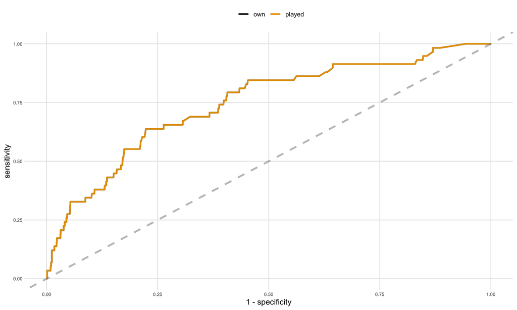

Another way to think about the model performance is to view its lift, or its ability to detect the positive outcomes over that of a null model. High lift indicates the model can much more quickly find all of the positive outcomes (in this case, games owned or played by the user), while a model with no lift is no better than random guessing.

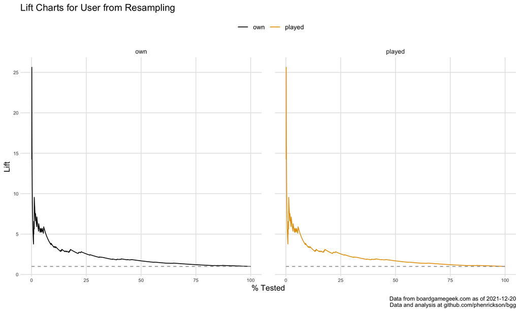

## 3.3 Most and Least Likely Games

What games does the model think jimmyhill27 is **most likely to own** that are **not** in their collection?

| username | yearpublished | game_id | name | pred_own | actual_own |
| --- | --- | --- | --- | --- | --- |
| jimmyhill27 | 1959 | 7688 | Memory | 0.50 | 0 |
| jimmyhill27 | 1900 | 45 | Perudo | 0.39 | 0 |
| jimmyhill27 | 2015 | 172242 | Exploding Kittens: NSFW Deck | 0.25 | 0 |
| jimmyhill27 | 1900 | 15878 | Rummy | 0.22 | 0 |
| jimmyhill27 | 1997 | 2633 | DOG | 0.21 | 0 |

What games does the model think jimmyhill27 is **least likely to own** that **are** in their collection?

| username | yearpublished | game_id | name | pred_own | actual_own |
| --- | --- | --- | --- | --- | --- |
| jimmyhill27 | 2015 | 173346 | 7 Wonders Duel | 0 | 1 |
| jimmyhill27 | 2019 | 269207 | The Taverns of Tiefenthal | 0 | 1 |
| jimmyhill27 | 2018 | 244521 | The Quacks of Quedlinburg | 0 | 1 |
| jimmyhill27 | 2013 | 146021 | Eldritch Horror | 0 | 1 |
| jimmyhill27 | 2006 | 27225 | Bananagrams | 0 | 1 |

## 3.4 Top Games by Year

Top 25 games most likely to be owned by the user in each year, highlighting in blue the games that the user has owned/played.

| rank | 2011 | 2012 | 2013 | 2014 | 2015 | 2016 | 2017 | 2018 | 2019 |
| --- | --- | --- | --- | --- | --- | --- | --- | --- | --- |
| 1 | Munchkin Axe Cop | Zombicide | The Doom That Came to Atlantic City | Smash Up: Monster Smash | Exploding Kittens: NSFW Deck | Terraforming Mars | The Godfather: Corleone's Empire | Rising Sun | Fire Tower |
| 2 | Takenoko | Coup | Prosperity | Dead of Winter: A Crossroads Game | Pandemic Legacy: Season 1 | Bloodborne: The Card Game | Pandemic Legacy: Season 2 | Everdell | Era: Medieval Age |
| 3 | Santiago de Cuba | The Cave | Legacy: The Testament of Duke de Crecy | Camel Up | Exploding Kittens | Smash Up: It's Your Fault! | Rum & Bones: Second Tide | A Pleasant Journey to Neko | Zombicide: Dark Side |
| 4 | Mondo | Smash Up | Risk: The Walking Dead – Survival Edition | Smash Up: Science Fiction Double Feature | Munchkin Gloom | Hit Z Road | Spirit Island | Luxor | The Magnificent |
| 5 | Pirate Fluxx | Guildhall | Smash Up: Awesome Level 9000 | Imperial Settlers | Haspelknecht | Coal Baron: The Great Card Game | Summit: The Board Game | The World of SMOG: Rise of Moloch | Zombicide: Invader |
| 6 | Drako: Dragon & Dwarves | Munchkin Conan | Coal Baron | Monopoly Deal | Tiny Epic Galaxies | Quadropolis | Massive Darkness | A Song of Ice & Fire: Tabletop Miniatures Game – Stark vs Lannister Starter Set | Cthulhu: Death May Die |
| 7 | Mage Knight Board Game | Exodus: Proxima Centauri | Tomorrow | La Fallera Calavera | Sylvion | Banana Bandits | Bears vs Babies | Newton | Western Empires |
| 8 | Eaten by Zombies! | Rent a Hero | Zombicide Season 2: Prison Outbreak | Sons of Anarchy: Men of Mayhem | Raptor | Raise Your Goblets | Indian Summer | Monopoly Cheaters Edition | Tiny Towns |
| 9 | Catan Histories: Merchants of Europe | Clash of Cultures | Sorry! with Fire & Ice Power-ups | Trekking the National Parks | Chaosmos | Evolution: Climate | Super Mario Bros. Power Up Card Game | Trekking the National Parks: Second Edition | Darwin's Choice |
| 10 | Killer Bunnies and the Conquest of the Magic Carrot | Seasons | Firefly: The Game | Evolution | Smash Up: Munchkin | Looterz | Smash Up: What Were We Thinking? | Catan Histories: Rise of the Inkas | Watergate |
| 11 | The Road to Canterbury | Il Vecchio | Guildhall: Job Faire | Five Tribes | OctoDice | Pandemic: Iberia | A Game of Thrones: Catan – Brotherhood of the Watch | Axis & Allies & Zombies | KeyForge: Age of Ascension |
| 12 | Village | Monopoly Millionaire | Monopoly Empire | Abyss | Epic PVP: Fantasy | The Manhattan Project: Energy Empire | Unstable Unicorns | Cosmic Encounter: 42nd Anniversary Edition | God of War: The Card Game |
| 13 | Feudalia | Trains | Cappuccino | Black Fleet | Mr Lister's Quiz Shootout | Exceed Fighting System | Oh Captain! | Smash Up: That '70s Expansion | PARKS |
| 14 | Battleship Galaxies | Lucky Numbers | Friese's Landlord | Beasty Bar | Mission: Red Planet (Second Edition) | Crazy Karts | Exploding Kittens: Party Pack | Coimbra | Naga Raja |
| 15 | Pastiche | The Big Bang Theory: The Party Game | Munchkin Legends | Colt Express | Three Cheers for Master | Citadels | Unfair | Petrichor | Living Planet |
| 16 | Eminent Domain | City of Horror | A Study in Emerald | Student Bodies | Munchkin Oz | The Bird Told Me to Do It | Smash Up: Big in Japan | Fireball Island: The Curse of Vul-Kar | Maracaibo |
| 17 | Resident Evil Deck Building Game: Alliance | The Manhattan Project | Smash Up: The Obligatory Cthulhu Set | Belle of the Ball | A Study in Emerald (Second Edition) | Junta: Las Cartas | Heaven & Ale | Monopoly Gamer: Mario Kart | Wacky Races: The Board Game |
| 18 | The Walking Dead Board Game | Neuroshima: Convoy | The Walking Dead Board Game: The Best Defense | Pandemic: The Cure | Smash Up: Pretty Pretty Smash Up | 13 Clues | Photosynthesis | The Grizzled: Armistice Edition | Harry Potter: Hogwarts Battle – Defence Against the Dark Arts |
| 19 | Struggle for Catan | Morels | Jungle Ascent | Saboteur: The Duel | Star Realms: Colony Wars | Evolution: The Beginning | Monopoly Gamer | The Walking Dead: No Sanctuary | Robin of Locksley |
| 20 | Bios: Megafauna | Serenissima (Second Edition) | Huida de Silver City | oddball Äeronauts | Blood Rage | 3 Wishes | SOW | Zombie Kidz Evolution | Unmatched: Robin Hood vs. Bigfoot |
| 21 | Tetris Link | Spartacus: A Game of Blood and Treachery | Coconuts | Waggle Dance | Above and Below | Smash Up: Cease and Desist | Outlive | Railroad Ink: Deep Blue Edition | Imperial Settlers: Empires of the North |
| 22 | Munchkin Zombies | Wiz-War (Eighth Edition) | Zpocalypse | Deus | Ylandyss | Bohnanza: The Duel | Breaking Bad: The Board Game | Narcos: The Board Game | Pangea |
| 23 | Mundus Novus | Miskatonic School for Girls | Munchkin Pathfinder | Catan: Ancient Egypt | Dojo Kun | Railroad Revolution | Dream On! | Haven | Era of Tribes |
| 24 | Cover Your Assets | Doctor Who: The Card Game | Dead Panic | Relic Expedition | Inhabit the Earth | Meeple War | Tavern Masters | Expancity | Nanty Narking |
| 25 | Panic Station | Uncharted: The Board Game | Race! Formula 90 | Arcadia Quest | Risk: Europe | Cottage Garden | InBetween | Way of the Panda | Dale of Merchants Collection |

## 3.5 Interactive Predictions from Resampling

Interactive table for predictions from resampling.

|  | username | yearpublished | rank | game_id | name | pred_played | pred_own | actual_played | actual_own |
| --- | --- | --- | --- | --- | --- | --- | --- | --- | --- |
| 1 | jimmyhill27 | 1900 | 2 | 45 | Perudo | 0.39 | 0.39 | 0 | 0 |
| 2 | jimmyhill27 | 1900 | 4 | 15878 | Rummy | 0.22 | 0.22 | 0 | 0 |
| 3 | jimmyhill27 | 1900 | 17 | 2386 | Chinese Checkers | 0.13 | 0.13 | 0 | 0 |
| 4 | jimmyhill27 | 1900 | 24 | 4792 | Tiddledy Winks | 0.11 | 0.11 | 0 | 0 |
| 5 | jimmyhill27 | 1900 | 27 | 2389 | Othello | 0.1 | 0.1 | 0 | 0 |
| 6 | jimmyhill27 | 1900 | 28 | 7316 | Bingo | 0.1 | 0.1 | 0 | 0 |
| 7 | jimmyhill27 | 1900 | 30 | 6424 | Pick Up Sticks | 0.1 | 0.1 | 0 | 0 |
| 8 | jimmyhill27 | 1900 | 31 | 2785 | Game of Goose | 0.1 | 0.1 | 0 | 0 |
| 9 | jimmyhill27 | 1900 | 33 | 11901 | Tic-Tac-Toe | 0.09 | 0.09 | 0 | 0 |
| 10 | jimmyhill27 | 1900 | 35 | 9851 | Shut the Box | 0.09 | 0.09 | 0 | 0 |

[output cut: 7426 more lines]

# 4 Validating the Model on 2020

How well did a model trained on a user’s collection through 2019 perform in predicting games for the user from 2020?

| username | outcome_type | yearpublished | .metric | .estimator | .estimate |
| --- | --- | --- | --- | --- | --- |
| jimmyhill27 | own | 2020 | roc_auc | binary | 0.315 |
| jimmyhill27 | played | 2020 | roc_auc | binary | 0.315 |

Table of top 25 games from 2020, highlighting games that the user owns.

| username | yearpublished | game_id | name | pred_own | pred_played | actual_own | actual_played |
| --- | --- | --- | --- | --- | --- | --- | --- |
| jimmyhill27 | 2020 | 232414 | Oceans | 0.07 | 0.07 | 0 | 0 |
| jimmyhill27 | 2020 | 252153 | Tang Garden | 0.06 | 0.06 | 0 | 0 |
| jimmyhill27 | 2020 | 317643 | Kyoto | 0.06 | 0.06 | 0 | 0 |
| jimmyhill27 | 2020 | 257001 | Munchkin Dungeon | 0.05 | 0.05 | 0 | 0 |
| jimmyhill27 | 2020 | 312346 | Munchkin Disney | 0.05 | 0.05 | 0 | 0 |
| jimmyhill27 | 2020 | 300001 | Renature | 0.04 | 0.04 | 0 | 0 |
| jimmyhill27 | 2020 | 308870 | Plotalot | 0.04 | 0.04 | 0 | 0 |
| jimmyhill27 | 2020 | 256317 | Guild Master | 0.03 | 0.03 | 0 | 0 |
| jimmyhill27 | 2020 | 286534 | The Quick and the Undead | 0.03 | 0.03 | 0 | 0 |
| jimmyhill27 | 2020 | 296043 | Four Gardens | 0.03 | 0.03 | 0 | 0 |
| jimmyhill27 | 2020 | 298572 | Cosmic Encounter Duel | 0.03 | 0.03 | 0 | 0 |
| jimmyhill27 | 2020 | 298764 | The Great Barrier Reef Card Game | 0.03 | 0.03 | 0 | 0 |
| jimmyhill27 | 2020 | 300442 | Trekking the World | 0.03 | 0.03 | 0 | 0 |
| jimmyhill27 | 2020 | 220133 | Endangered | 0.02 | 0.02 | 0 | 0 |
| jimmyhill27 | 2020 | 236713 | Sea of Plunder | 0.02 | 0.02 | 0 | 0 |
| jimmyhill27 | 2020 | 236861 | Full Moon Jacket | 0.02 | 0.02 | 0 | 0 |
| jimmyhill27 | 2020 | 245659 | Vampire: The Masquerade – Vendetta | 0.02 | 0.02 | 0 | 0 |
| jimmyhill27 | 2020 | 248182 | Solar City | 0.02 | 0.02 | 0 | 0 |
| jimmyhill27 | 2020 | 253506 | Versailles 1919 | 0.02 | 0.02 | 0 | 0 |
| jimmyhill27 | 2020 | 256609 | Nunami | 0.02 | 0.02 | 0 | 0 |
| jimmyhill27 | 2020 | 270239 | Moonrakers | 0.02 | 0.02 | 0 | 0 |
| jimmyhill27 | 2020 | 274841 | Cóatl | 0.02 | 0.02 | 0 | 0 |
| jimmyhill27 | 2020 | 277927 | Bites | 0.02 | 0.02 | 0 | 0 |
| jimmyhill27 | 2020 | 279900 | Afternova | 0.02 | 0.02 | 0 | 0 |
| jimmyhill27 | 2020 | 281094 | Plunder: A Pirate's Life | 0.02 | 0.02 | 0 | 0 |

# 5 Predicting Upcoming Games (2020 and On) for **jimmyhill27**

Examine the top games for the test set.

| username | yearpublished | game_id | name | rank | own | played |
| --- | --- | --- | --- | --- | --- | --- |
| jimmyhill27 | 2020 | 232414 | Oceans | 1 | 0.07 | 0.07 |
| jimmyhill27 | 2020 | 252153 | Tang Garden | 2 | 0.06 | 0.06 |
| jimmyhill27 | 2020 | 317643 | Kyoto | 3 | 0.06 | 0.06 |
| jimmyhill27 | 2020 | 312346 | Munchkin Disney | 4 | 0.05 | 0.05 |
| jimmyhill27 | 2020 | 257001 | Munchkin Dungeon | 5 | 0.05 | 0.05 |
| jimmyhill27 | 2020 | 308870 | Plotalot | 6 | 0.04 | 0.04 |
| jimmyhill27 | 2020 | 300001 | Renature | 7 | 0.04 | 0.04 |
| jimmyhill27 | 2020 | 286534 | The Quick and the Undead | 8 | 0.03 | 0.03 |
| jimmyhill27 | 2020 | 256317 | Guild Master | 9 | 0.03 | 0.03 |
| jimmyhill27 | 2020 | 298572 | Cosmic Encounter Duel | 10 | 0.03 | 0.03 |
| jimmyhill27 | 2020 | 298764 | The Great Barrier Reef Card Game | 11 | 0.03 | 0.03 |
| jimmyhill27 | 2020 | 300442 | Trekking the World | 12 | 0.03 | 0.03 |
| jimmyhill27 | 2020 | 296043 | Four Gardens | 13 | 0.03 | 0.03 |
| jimmyhill27 | 2020 | 279900 | Afternova | 14 | 0.02 | 0.02 |
| jimmyhill27 | 2020 | 281094 | Plunder: A Pirate's Life | 15 | 0.02 | 0.02 |
| jimmyhill27 | 2020 | 284665 | Board Royale: The Island | 16 | 0.02 | 0.02 |
| jimmyhill27 | 2020 | 282922 | Windward | 17 | 0.02 | 0.02 |
| jimmyhill27 | 2020 | 299452 | Dale of Merchants 3 | 18 | 0.02 | 0.02 |
| jimmyhill27 | 2020 | 302926 | Silver Coin | 19 | 0.02 | 0.02 |
| jimmyhill27 | 2020 | 321506 | Fröccs | 20 | 0.02 | 0.02 |
| jimmyhill27 | 2020 | 236713 | Sea of Plunder | 21 | 0.02 | 0.02 |
| jimmyhill27 | 2020 | 245659 | Vampire: The Masquerade – Vendetta | 22 | 0.02 | 0.02 |
| jimmyhill27 | 2020 | 270239 | Moonrakers | 23 | 0.02 | 0.02 |
| jimmyhill27 | 2020 | 299252 | Here to Slay | 24 | 0.02 | 0.02 |
| jimmyhill27 | 2020 | 298147 | Einer geht noch! | 25 | 0.02 | 0.02 |
| jimmyhill27 | 2021 | 282700 | LOOP: Life of Ordinary People | 1 | 0.07 | 0.07 |
| jimmyhill27 | 2021 | 304666 | Wild Life: The Card Game | 2 | 0.07 | 0.07 |
| jimmyhill27 | 2021 | 342942 | Ark Nova | 3 | 0.06 | 0.06 |
| jimmyhill27 | 2021 | 337269 | Terra Futura | 4 | 0.05 | 0.05 |
| jimmyhill27 | 2021 | 314491 | Meadow | 5 | 0.05 | 0.05 |
| jimmyhill27 | 2021 | 273330 | Bloodborne: The Board Game | 6 | 0.04 | 0.04 |
| jimmyhill27 | 2021 | 275061 | Rulebenders | 7 | 0.04 | 0.04 |
| jimmyhill27 | 2021 | 329465 | Red Rising | 8 | 0.03 | 0.03 |
| jimmyhill27 | 2021 | 257305 | SHASN | 9 | 0.03 | 0.03 |
| jimmyhill27 | 2021 | 316786 | Tabannusi: Builders of Ur | 10 | 0.03 | 0.03 |
| jimmyhill27 | 2021 | 245994 | The Dead Eye | 11 | 0.03 | 0.03 |
| jimmyhill27 | 2021 | 314503 | Codex Naturalis | 12 | 0.03 | 0.03 |
| jimmyhill27 | 2021 | 319792 | Fly-A-Way | 13 | 0.03 | 0.03 |
| jimmyhill27 | 2021 | 264164 | Night of the Living Dead: A Zombicide Game | 14 | 0.03 | 0.03 |
| jimmyhill27 | 2021 | 286751 | Zombicide: 2nd Edition | 15 | 0.03 | 0.03 |
| jimmyhill27 | 2021 | 342848 | World of Warcraft: Wrath of the Lich King | 16 | 0.03 | 0.03 |
| jimmyhill27 | 2021 | 274861 | Venice | 17 | 0.02 | 0.02 |
| jimmyhill27 | 2021 | 331685 | Hit the Silk! | 18 | 0.02 | 0.02 |
| jimmyhill27 | 2021 | 211364 | Seize the Bean | 19 | 0.02 | 0.02 |
| jimmyhill27 | 2021 | 230967 | Verrix | 20 | 0.02 | 0.02 |
| jimmyhill27 | 2021 | 284653 | Mind MGMT: The Psychic Espionage “Game.” | 21 | 0.02 | 0.02 |
| jimmyhill27 | 2021 | 335764 | Unmatched: Battle of Legends, Volume Two | 22 | 0.02 | 0.02 |
| jimmyhill27 | 2021 | 341169 | Great Western Trail (Second Edition) | 23 | 0.02 | 0.02 |
| jimmyhill27 | 2021 | 331635 | Kameloot | 24 | 0.02 | 0.02 |
| jimmyhill27 | 2021 | 320446 | Corduba 27 a.C. | 25 | 0.02 | 0.02 |
| jimmyhill27 | 2022 | 320718 | Hidden Leaders | 1 | 0.04 | 0.04 |
| jimmyhill27 | 2022 | 317511 | Tindaya | 2 | 0.03 | 0.03 |
| jimmyhill27 | 2022 | 348463 | ECO: Coral Reef | 3 | 0.03 | 0.03 |
| jimmyhill27 | 2022 | 339592 | Sheep in Disguise | 4 | 0.02 | 0.02 |
| jimmyhill27 | 2022 | 321608 | Hegemony: Lead Your Class to Victory | 5 | 0.02 | 0.02 |
| jimmyhill27 | 2022 | 318450 | Bios: Mesofauna | 6 | 0.02 | 0.02 |
| jimmyhill27 | 2022 | 306311 | Eternal Palace | 7 | 0.02 | 0.02 |
| jimmyhill27 | 2022 | 342246 | Feuding Foodies | 8 | 0.02 | 0.02 |
| jimmyhill27 | 2022 | 334065 | Verdant | 9 | 0.02 | 0.02 |
| jimmyhill27 | 2022 | 293941 | Mage Noir | 10 | 0.02 | 0.02 |
| jimmyhill27 | 2022 | 258779 | Planet Unknown | 11 | 0.01 | 0.01 |
| jimmyhill27 | 2022 | 284118 | Mechanical Beast | 12 | 0.01 | 0.01 |
| jimmyhill27 | 2022 | 329551 | Mosaic: A Story of Civilization | 13 | 0.01 | 0.01 |
| jimmyhill27 | 2022 | 286063 | The 7th Citadel | 14 | 0.01 | 0.01 |
| jimmyhill27 | 2022 | 303731 | Primal: The Awakening | 15 | 0.01 | 0.01 |
| jimmyhill27 | 2022 | 287871 | Hybris: Disordered Cosmos | 16 | 0.01 | 0.01 |
| jimmyhill27 | 2022 | 322589 | Zapotec | 17 | 0.01 | 0.01 |
| jimmyhill27 | 2022 | 343900 | Senjutsu: Battle For Japan | 18 | 0.01 | 0.01 |
| jimmyhill27 | 2022 | 282775 | The Warp | 19 | 0.01 | 0.01 |
| jimmyhill27 | 2022 | 342444 | Black Rose Wars: Rebirth | 20 | 0.01 | 0.01 |
| jimmyhill27 | 2022 | 295770 | Frosthaven | 21 | 0.01 | 0.01 |
| jimmyhill27 | 2022 | 315695 | Veiled Fate | 22 | 0.01 | 0.01 |
| jimmyhill27 | 2022 | 319910 | Pagan: Fate of Roanoke | 23 | 0.01 | 0.01 |
| jimmyhill27 | 2022 | 299106 | Fractal: Beyond the Void | 24 | 0.01 | 0.01 |
| jimmyhill27 | 2022 | 273814 | Deliverance | 25 | 0.01 | 0.01 |

## 5.1 Interactive Table for Upcoming Games 2020 and On

|  | username | yearpublished | game_id | name | rank | own | played |
| --- | --- | --- | --- | --- | --- | --- | --- |
| 1 | jimmyhill27 | 2020 | 232414 | Oceans | 1 | 0.07 | 0.07 |
| 2 | jimmyhill27 | 2021 | 282700 | LOOP: Life of Ordinary People | 2 | 0.07 | 0.07 |
| 3 | jimmyhill27 | 2021 | 304666 | Wild Life: The Card Game | 3 | 0.07 | 0.07 |
| 4 | jimmyhill27 | 2020 | 252153 | Tang Garden | 4 | 0.06 | 0.06 |
| 5 | jimmyhill27 | 2021 | 342942 | Ark Nova | 5 | 0.06 | 0.06 |
| 6 | jimmyhill27 | 2020 | 317643 | Kyoto | 6 | 0.06 | 0.06 |
| 7 | jimmyhill27 | 2020 | 312346 | Munchkin Disney | 7 | 0.05 | 0.05 |
| 8 | jimmyhill27 | 2020 | 257001 | Munchkin Dungeon | 8 | 0.05 | 0.05 |
| 9 | jimmyhill27 | 2021 | 337269 | Terra Futura | 9 | 0.05 | 0.05 |
| 10 | jimmyhill27 | 2021 | 314491 | Meadow | 10 | 0.05 | 0.05 |

[output cut: 1627 more lines]